# Project Zoidberg

The purpose of this project is to compare different type of Artificial Inteligence (AI) in order to help doctors detecting pneumonia. Given some X-ray images, we will use machine learning to detect pneumonia.

**Choice of algorithms**

We chose to implement 4 differents machine learning algorithms:

- k-Nearest Neighbors ([KNN](https://scikit-learn.org/stable/modules/neighbors.html)) with scikit-learn
- Support Vector Machine ([SVM](https://scikit-learn.org/stable/modules/svm.html)) with scikit-learn
- Naive Bayes ([NB](https://scikit-learn.org/stable/modules/naive_bayes.html)) with scikit-learn
- Convolutionnal Neural Network ([CNN](https://en.wikipedia.org/wiki/Convolutional_neural_network) with keras (tensorflow))

## I - Imports and Loading dataset

### 1 - Imports

```python
#General imports
import os, os.path
import numpy as np
import pandas as pd
import random
import numpy as np
import time

import cv2
import matplotlib.pyplot as plt
%matplotlib inline
from tqdm import tqdm

#imports for KNN
from sklearn.neighbors import KNeighborsClassifier

#Imports for CNN
import tensorflow as tf
import keras.backend as K
from keras.models import Model, Sequential
from keras.layers import Input, Dense, Flatten, Dropout, BatchNormalization
from keras.layers import Conv2D, SeparableConv2D, MaxPool2D, LeakyReLU, Activation
from tensorflow.keras.optimizers import Adam
from keras.preprocessing.image import ImageDataGenerator
from keras.callbacks import ModelCheckpoint, ReduceLROnPlateau, EarlyStopping

#Import for SVM
import sklearn
from sklearn import svm
from sklearn.pipeline import make_pipeline
from sklearn.preprocessing import StandardScaler

#Imports fo Naive Bayes
from sklearn.naive_bayes import GaussianNB, MultinomialNB, ComplementNB, BernoulliNB, CategoricalNB

#Imports for metrics
from sklearn.metrics import accuracy_score, confusion_matrix, roc_curve, auc, log_loss
import matplotlib.colors as mcolors

#Generation of seed
seed = 232
np.random.seed(seed)
tf.random.set_seed(seed)

#Imports for Transfer Learning
import glob
```

[output not shown]

### 2 - Load dataset

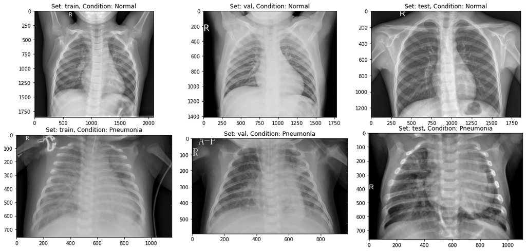

```python
input_path = './dataset/'

fig, ax = plt.subplots(2, 3, figsize=(15, 7))
ax = ax.ravel()
plt.tight_layout()

for i, _set in enumerate(['train', 'val', 'test']):
    set_path = input_path+_set
    ax[i].imshow(plt.imread(set_path+'/NORMAL/'+os.listdir(set_path+'/NORMAL')[0]), cmap='gray')
    ax[i].set_title('Set: {}, Condition: Normal'.format(_set))
    ax[i+3].imshow(plt.imread(set_path+'/PNEUMONIA/'+os.listdir(set_path+'/PNEUMONIA')[0]), cmap='gray')
    ax[i+3].set_title('Set: {}, Condition: Pneumonia'.format(_set))
```

```python
for _set in ['train', 'val', 'test']:
    n_normal = len(os.listdir(input_path + _set + '/NORMAL'))
    n_infect = len(os.listdir(input_path + _set + '/PNEUMONIA'))
    print('Set: {}, normal images: {}, pneumonia images: {}'.format(_set, n_normal, n_infect))
```

```
Set: train, normal images: 1341, pneumonia images: 3875
Set: val, normal images: 8, pneumonia images: 8
Set: test, normal images: 234, pneumonia images: 390
```

## II - KNN

### 1 - Pre-process

```python
def parse_input(negatives_path, positives_path):
    images = list()
    labels = list()

    negative_files = os.listdir(negatives_path)
    positive_files = os.listdir(positives_path)
    total = len(negative_files) + len(positive_files)

    with tqdm(total=100) as pbar:
        for file in negative_files:
            if file.endswith('.jpeg') == False:
                continue
            images.append(cv2.imread(negatives_path + '/' + file, cv2.IMREAD_GRAYSCALE))
            labels.append(0)
            pbar.update(100/total)

        for file in positive_files:
            if file.endswith('.jpeg') == False:
                continue
            images.append(cv2.imread(positives_path + '/' + file, cv2.IMREAD_GRAYSCALE))
            labels.append(1)
            pbar.update(100/total)

    return images, labels
```

```python
def resize_images(images, target_dimensions):
    resized_images = np.empty((len(images), target_dimensions[0] * target_dimensions[1]))
    i = 0
    print(resized_images.shape)
    for img in tqdm(images):
        resized_images[i] = cv2.resize(img, target_dimensions).reshape((target_dimensions[0] * target_dimensions[1]))
        i += 1
    return resized_images
```

```python
base_path = "./dataset"
raw_train_images, train_labels = parse_input(base_path + '/train/NORMAL', base_path + '/train/PNEUMONIA')
raw_test_images, test_labels = parse_input(base_path + '/test/NORMAL', base_path + '/test/PNEUMONIA')
```

```python
target_dimensions = (200, 200)
train_images = np.array(resize_images(raw_train_images, target_dimensions))
train_images = train_images.reshape((train_images.shape[0], 200 * 200));

test_images = np.array(resize_images(raw_test_images, target_dimensions))
test_images = test_images.reshape((test_images.shape[0], 200 * 200));
```

```
(5216, 40000)
```

```
(624, 40000)
```

This is the function that call the scikit-learn implementation of the KNN model. For a given value of K (and the dataset), it returns the following metrics:

- the number of nearest neighbors (k)
- the duration of the training phase
- the components of the confusion matrix (true positives, true negatives, false positives, false negatives)
- the accuracy of the model
- the logloss
- the duration of the scoring phase

```python
def knn(train_images, train_labels, test_images, test_labels, k):
    start_time = time.time()
    KNN=KNeighborsClassifier(k, n_jobs=-1)
    KNN.fit(train_images, train_labels)
    training_duration = time.time() - start_time

    start_time = time.time()

    true_positives = 0
    true_negatives = 0
    false_positives = 0
    false_negatives = 0
    res = KNN.predict_proba(test_images)
    predictions = []

    for i in range(len(test_images)):

        prediction = np.argmax(res[i], axis=0)
        current_label = test_labels[i]
        predictions.append(res[prediction])

        if (prediction == current_label):
            if (prediction == 1):
                true_positives += 1
            else:
                true_negatives += 1
        else:
            if (prediction == 1):
                false_positives += 1
            else:
                false_negatives += 1

    logloss = log_loss(test_labels, predictions)
    accuracy = (true_positives + true_negatives) / len(test_images)
    prediction_time = time.time() - start_time

    return [k, training_duration, true_positives, true_negatives, false_positives, false_negatives, accuracy, res, logloss, prediction_time]
```

A run of the KNN model on this dataset with k ∈ [1, 100] returned this accuracy curve.

[figure not shown]

```python
knn_result_2 = knn(train_images, train_labels, test_images, test_labels, 2)
knn_result_5 = knn(train_images, train_labels, test_images, test_labels, 2)

KNN_training_duration_2 = knn_result_2[1]
KNN_TP_2 = knn_result_2[2]
KNN_TN_2 = knn_result_2[3]
KNN_FP_2 = knn_result_2[4]
KNN_FN_2 = knn_result_2[5]
KNN_accuracy_2 = knn_result_2[6]
KNN_logloss_2 = knn_result_2[7]
KNN_log_loss_2 = knn_result_2[8]
KNN_prediction_time_2 = knn_result_2[9]
```

```python
def confusionmatrix(TNs, FNs, FPs, TPs, k, accuracy):
      fig, ax = plt.subplots(1,1)
      fig.set_figheight(2)
      data=[["confusion matrix for k = " + str(k), "Actual NORMAL", "Actual PNEUMONIA"],
            ["Predicted NORMAL",TNs,FNs],
            ["Predicted PNEUMONIA" ,FPs,TPs]]
      colors=[['w', 'w', 'w'],["w", "green", "red"],[ "w","red", "green"]]
      ax.axis('off')
      table = ax.table(cellText=data,loc="center", cellColours=colors, colLoc='center', rowLoc='center', colWidths=[0.3, 0.2, 0.2])
      table.auto_set_font_size(False)
      table.set_fontsize(12)
      table.scale(2, 2)
      plt.title('confusion matrix for k = ' + str(k) + ' (acc ' + str(accuracy) +'%)')
      plt.show()
```

This is the confusion matrix for the value of k that entails the **highest accuracy** and the **least amount of false positives**.

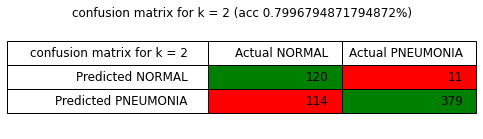

```python
confusionmatrix(KNN_TN_2, KNN_FN_2, KNN_FP_2, KNN_TP_2, 2, KNN_accuracy_2)
```

Confusion matrix of the value of k that yields the most accurate predictions

```python
scores_knn = {"Loss": KNN_logloss_2 , "Accuracy": KNN_accuracy_2, "Precision": KNN_TP_2/(KNN_TP_2+KNN_FP_2)*100, "Recall": KNN_TP_2/(KNN_TP_2+KNN_FP_2)*100,
    "FN": KNN_FN_2, "FP": KNN_FP_2, "TN": KNN_TN_2, "TP": KNN_TP_2, "AUC": None}
```

## III - SVM

### Data processing

```python
def get_and_process_data(path, image_size):
    data_array = os.listdir(path)
    data = list()
    for img in tqdm(data_array):
        try:
            img_arr = cv2.imread(os.path.join(path, img), cv2.IMREAD_GRAYSCALE)
            resized_array = cv2.resize(img_arr, (image_size, image_size))
            #squasing the array in 2D
            reshaped_array = resized_array.reshape(image_size * image_size)
            data.append(reshaped_array)
        except Exception as e:
            print(e)
    return np.array(data)
```

```python
dataset_location = './dataset'
image_size = 300
train_pneumonia = get_and_process_data(dataset_location+'/train/PNEUMONIA', image_size)
train_normal = get_and_process_data(dataset_location+'/train/NORMAL', image_size)
test_pneumonia = get_and_process_data(dataset_location+'/test/PNEUMONIA', image_size)
test_normal = get_and_process_data(dataset_location+'/test/NORMAL', image_size)
```

```
OpenCV(4.5.5) /io/opencv/modules/imgproc/src/resize.cpp:4052: error: (-215:Assertion failed) !ssize.empty() in function 'resize'
```

```
OpenCV(4.5.5) /io/opencv/modules/imgproc/src/resize.cpp:4052: error: (-215:Assertion failed) !ssize.empty() in function 'resize'
```

```python
# 0 = NORMAL, 1 = PNEUMONIA
train_x, train_y, test_x, test_y = list(), list(), list(), list()
for img in tqdm(train_pneumonia):
    train_x.append(img)
    train_y.append(1)
for img in tqdm(train_normal):
    train_x.append(img)
    train_y.append(0)
for img in tqdm(test_pneumonia):
    test_x.append(img)
    test_y.append(1)
for img in tqdm(test_normal):
    test_x.append(img)
    test_y.append(0)
```

### Training

#### SVC - Support Vector Classification

SVC only keeps part of the training dataset because its cost function ignores data beyond the margin.

##### Linear SVC

LinearSVC is a faster implementions of SVC because it only uses a linear kernel.

While the svm.LinearSVC() model is more optimized and slightly faster than svm.SVC(kernel='linear'), it does not returns probabilities but only the most probable label. Since we need to calculate the roc auc to compare it to the other models, we will use svm.SVC(kernel='linear',probability=True).

```python
linearSVC = make_pipeline(StandardScaler(),svm.SVC(kernel='linear',probability=True))
# linearSVC = make_pipeline(StandardScaler(),svm.LinearSVC())
```

```python
linearSVC_model = linearSVC.fit(train_x, train_y)
```

#### Accuracy

```python
linearSVC_y_pred = linearSVC_model.predict(test_x)
```

```python
linearSVC_y_pred_proba = linearSVC_model.predict_proba(test_x)
```

```python
linearSVC_score = linearSVC_model.score(test_x, test_y)
print('linearSVC score: %f' % linearSVC_score)
```

```
linearSVC score: 0.740385
```

```python
svcLogLoss = log_loss(test_y, linearSVC_y_pred_proba)
linearSVCCm = sklearn.metrics.confusion_matrix(test_y, linearSVC_y_pred)
svcTn, svcFp, svcFn, svcTp = linearSVCCm.ravel()
svcFpr, svcTpr, svcTreshold = roc_curve(test_y, linearSVC_y_pred, pos_label=1)
svcRoc_auc = auc(svcFpr, svcTpr)
```

```python
scores_svm = {"Loss": svcLogLoss, "Accuracy": linearSVC_score, "Precision": svcTp/(svcTp+svcFp)*100, "Recall": svcTp/(svcTp+svcFn)*100,
    "FN": svcFn, "FP": svcFp, "TN": svcTn, "TP": svcTp, "AUC": svcRoc_auc}
scores_svm
```

```
{'Loss': 1.0467845377407006,
 'Accuracy': 0.7403846153846154,
 'Precision': 71.03321033210332,
 'Recall': 98.71794871794873,
 'FN': 5,
 'FP': 157,
 'TN': 77,
 'TP': 385,
 'AUC': 0.6581196581196582}
```

## IV - Naive Bayes

#### Gaussian Naive Bayes

The gaussian model assumes the distribution of features to be gaussian in a binomial distribution.

This model was selected among all Naive Bayes models because it had the least false negative and highest accuracy amongst its fellow Naive Bayes models. This was to be expected since the other are made for multinomial distributions.

It is the best model by killing "only" 21% of the patients having pneumonia.

While the Gaussian Naive Bayes model has a slightly higher false positive ratio than the Multinomial and Complement, it has by far the lowest false negative (patient with pneumonia detected as sane) which is the most important metrics since it means the death of the patient.

### Training

```python
gnb = GaussianNB()
gnb_model = gnb.fit(train_x, train_y)
```

### Metrics

#### Accuracy

```python
gnb_y_pred = gnb_model.predict(test_x)
gnb_y_pred_proba = gnb_model.predict_proba(test_x)
gnb_acc = gnb_model.score(test_x, test_y)
```

```python
nbLogLoss = log_loss(test_y, gnb_y_pred_proba)
nbCm = sklearn.metrics.confusion_matrix(test_y, gnb_y_pred)
nbTn, nbFp, nbFn, nbTp = nbCm.ravel()
nbFpr, nbTpr, nbTreshold = roc_curve(test_y, gnb_y_pred, pos_label=1)
nbRoc_auc = auc(nbFpr, nbTpr)
```

```python
scores_nb = {"Loss": nbLogLoss, "Accuracy": gnb_acc, "Precision": nbTp/(nbTp+nbFp)*100, "Recall": nbTp/(nbTp+nbFn)*100,
    "FN": nbFn, "FP": nbFp, "TN": nbTn, "TP": nbTp, "AUC": nbRoc_auc}
scores_nb
```

```
{'Loss': 9.350837302659755,
 'Accuracy': 0.7275641025641025,
 'Precision': 77.63819095477386,
 'Recall': 79.23076923076923,
 'FN': 81,
 'FP': 89,
 'TN': 145,
 'TP': 309,
 'AUC': 0.7059829059829059}
```

```python
NB_score = gnb_model.score(test_x, test_y)
print('gnb score: %f' % NB_score)
```

```
gnb score: 0.727564
```

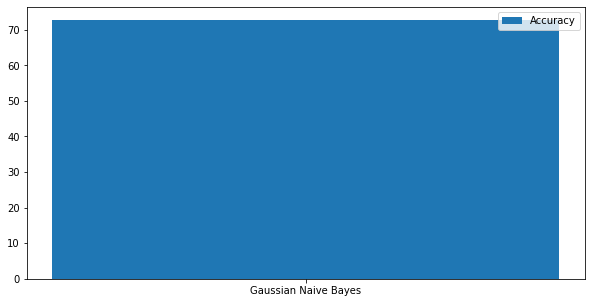

```python
NBacc = {
    "Gaussian Naive Bayes": gnb_model.score(test_x, test_y),
}

modelNames=list(NBacc.keys())
acc=[x*100 for x in NBacc.values()]

xAxis=np.arange(len(modelNames))
plt.figure(figsize=(10,5))

plt.bar(xAxis, acc, width=0.4, label="Accuracy")
plt.xticks(xAxis, modelNames)
plt.legend()


plt.show()
```

#### False negatives (deaths)

```python
def analyzeConfusionMatrix(model, cm):
    falsePositiveRatio = cm[0][1]/sum(cm[0])*100
    print(model, 'falsely detected ', "{:.2f}".format(falsePositiveRatio), '% of sane patients as having pneumonia')
    deadRatio = cm[1][0]/sum(cm[1])*100
    print(model,' killed ',"{:.2f}".format(deadRatio), '% of the ill patients')
    print()
    return deadRatio
```

```python
gnbCm = confusion_matrix(test_y, gnb_y_pred)

preds = {
    "Gaussian Naive Bayes": gnbCm,
}

for key, value in preds.items():
    analyzeConfusionMatrix(key, value)
```

```
Gaussian Naive Bayes falsely detected  38.03 % of sane patients as having pneumonia
Gaussian Naive Bayes  killed  20.77 % of the ill patients
```

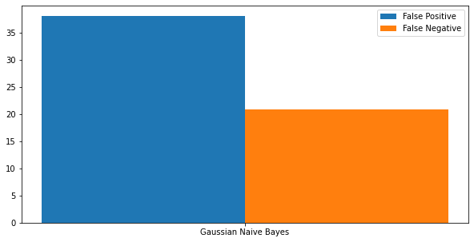

```python
modelNames=list(preds.keys())
fp=[x[0][1]/sum(x[0])*100 for x in preds.values()]
fn=[x[1][0]/sum(x[1])*100 for x in preds.values()]

xAxis=np.arange(len(modelNames))
plt.figure(figsize=(10,5))

plt.bar(xAxis -0.2, fp, width=0.4, label="False Positive")
plt.bar(xAxis +0.2, fn, width=0.4, label="False Negative")
plt.xticks(xAxis, modelNames)
plt.legend()


plt.show()
```

## V - CNN

### 1 - Process data

```python
def process_data(img_dims, batch_size):
    # Initialize Data Augmentation
    train_datagen = ImageDataGenerator(rescale=1./255, zoom_range=0.3, vertical_flip=False)
    test_val_datagen = ImageDataGenerator(rescale=1./255)

    # Import training set
    train_gen = train_datagen.flow_from_directory(
        directory=input_path+'train',
        target_size=(img_dims, img_dims),
        batch_size=batch_size,
        class_mode='binary',
        shuffle=True)

    # Import testing set
    test_gen = test_val_datagen.flow_from_directory(
        directory=input_path+'test',
        target_size=(img_dims, img_dims),
        batch_size=batch_size,
        class_mode='binary',
        shuffle=True)

    # Import Validation set
    val_gen = test_val_datagen.flow_from_directory(
        directory=input_path+'val',
        target_size=(img_dims, img_dims),
        batch_size=batch_size,
        class_mode='binary',
        shuffle=True)

    test_data = []
    test_labels = []

    # Seperate Test images and labeks
    for cond in ['/NORMAL/', '/PNEUMONIA/']:
        for img in (os.listdir(input_path + 'test' + cond)):
            img = plt.imread(input_path+'test'+cond+img)
            img = cv2.resize(img, (img_dims, img_dims))
            img = np.dstack([img, img, img])
            img = img.astype('float32') / 255
            if cond=='/NORMAL/':
                label = 0
            elif cond=='/PNEUMONIA/':
                label = 1
            test_data.append(img)
            test_labels.append(label)

    test_data = np.array(test_data)
    test_labels = np.array(test_labels)

    return train_gen, test_gen, test_data, test_labels, val_gen
```

```python
def count_image(input_path):
    _set = 'train'
    count_normal = len(os.listdir(input_path + _set + '/NORMAL'))
    count_pneumonia = len(os.listdir(input_path + _set + '/PNEUMONIA'))

    return count_normal, count_pneumonia
```

```python
epochs = 20
batch_size = 32
image_size = 150

train_gen, test_gen, test_data, test_labels, val_gen = process_data(image_size, batch_size)
count_normal, count_pneumonia = count_image(input_path)
```

```
Found 5216 images belonging to 2 classes.
Found 624 images belonging to 2 classes.
Found 16 images belonging to 2 classes.
```

### 2 - Create Model

```python
initial_bias = np.log([count_pneumonia/count_normal])
initial_bias
```

```
array([1.06113006])
```

```python
weight_for_0 = (1 / count_normal)*(train_gen.samples)/2.0
weight_for_1 = (1 / count_pneumonia)*(train_gen.samples)/2.0

class_weight = {0: weight_for_0, 1: weight_for_1}

final_bias = np.log([weight_for_1 * count_pneumonia/weight_for_0 * count_normal])
print('Final bias: ', final_bias)

print('Weight for class 0: {:.2f}'.format(weight_for_0))
print('Weight for class 1: {:.2f}'.format(weight_for_1))
```

```
Final bias:  [14.40234177]
Weight for class 0: 1.94
Weight for class 1: 0.67
```

```python
inputs = Input(shape=(image_size, image_size, 3))

# First conv block
x = Conv2D(filters=16, kernel_size=(3, 3), activation='relu', padding='same')(inputs)
x = Conv2D(filters=16, kernel_size=(3, 3), activation='relu', padding='same')(x)
x = MaxPool2D(pool_size=(2, 2))(x)

# Second conv block
x = SeparableConv2D(filters=32, kernel_size=(3, 3), activation='relu', padding='same')(x)
x = SeparableConv2D(filters=32, kernel_size=(3, 3), activation='relu', padding='same')(x)
x = BatchNormalization()(x)
x = MaxPool2D(pool_size=(2, 2))(x)

# Third conv block
x = SeparableConv2D(filters=64, kernel_size=(3, 3), activation='relu', padding='same')(x)
x = SeparableConv2D(filters=64, kernel_size=(3, 3), activation='relu', padding='same')(x)
x = BatchNormalization()(x)
x = MaxPool2D(pool_size=(2, 2))(x)

# Fourth conv block
x = SeparableConv2D(filters=128, kernel_size=(3, 3), activation='relu', padding='same')(x)
x = SeparableConv2D(filters=128, kernel_size=(3, 3), activation='relu', padding='same')(x)
x = BatchNormalization()(x)
x = MaxPool2D(pool_size=(2, 2))(x)
x = Dropout(rate=0.2)(x)

# Fifth conv block
x = SeparableConv2D(filters=256, kernel_size=(3, 3), activation='relu', padding='same')(x)
x = SeparableConv2D(filters=256, kernel_size=(3, 3), activation='relu', padding='same')(x)
x = BatchNormalization()(x)
x = MaxPool2D(pool_size=(2, 2))(x)
x = Dropout(rate=0.2)(x)

# FC layer
x = Flatten()(x)
x = Dense(units=512, activation='relu')(x)
x = Dropout(rate=0.7)(x)
x = Dense(units=128, activation='relu')(x)
x = Dropout(rate=0.5)(x)
x = Dense(units=64, activation='relu')(x)
x = Dropout(rate=0.3)(x)

# Output layer
output = Dense(units=1, activation='sigmoid')(x)
```

```python
model = Model(inputs=inputs, outputs=output)

METRICS = [
    'accuracy',
    tf.keras.metrics.Precision(name='precision'),
    tf.keras.metrics.Recall(name='recall'),
    tf.keras.metrics.FalseNegatives(name='fn'),
    tf.keras.metrics.FalsePositives(name='fp'),
    tf.keras.metrics.TrueNegatives(name='tn'),
    tf.keras.metrics.TruePositives(name='tp'),
    tf.keras.metrics.AUC(name='AUC')]

model.compile(
    optimizer='adam',
    loss='binary_crossentropy',
    metrics=METRICS)
```

```python
history = model.fit(
            train_gen,
            steps_per_epoch = train_gen.samples // batch_size,
            epochs = epochs,
            validation_data = val_gen,
            validation_steps = val_gen.samples // batch_size,
            class_weight = class_weight)
```

### 3 - Fine Tuning the Model

```python
checkpoint_cb = tf.keras.callbacks.ModelCheckpoint("xray_model2.h5", save_best_only=True)
early_stopping_cb = tf.keras.callbacks.EarlyStopping(patience=10, restore_best_weights=True)
```

```python
def exponential_decay(lr0, s):
    def exponential_decay_fn(epoch):
        return lr0 * 0.1 **(epoch / s)
    return exponential_decay_fn

exponential_decay_fn = exponential_decay(0.01, 20)

lr_scheduler = tf.keras.callbacks.LearningRateScheduler(exponential_decay_fn)
```

```python
hist = model.fit(
    train_gen,
    steps_per_epoch = train_gen.samples // batch_size,
    epochs=1,
    validation_data = test_gen,
    validation_steps = test_gen.samples // batch_size,
    class_weight = class_weight,
    callbacks = [checkpoint_cb, early_stopping_cb, lr_scheduler]
)
```

### 4 - Metrics

```python
# Evaluating the model on train and test
score = model.evaluate(train_gen)

print("Train Loss: ", score[0])
print("Train Accuracy: ", score[1])

score_cnn_test = model.evaluate(test_gen)
print("\nTest loss: ", score_cnn_test[0])
print("Test Accuracy: ", score_cnn_test[1])
```

```
Train Loss:  0.6934109330177307
Train Accuracy:  0.25709354877471924

Test loss:  0.6932830810546875
Test Accuracy:  0.375
```

[figure not shown]

```python
fig, ax = plt.subplots(1, 2, figsize=(10, 3))
ax = ax.ravel()

for i, met in enumerate(['accuracy', 'loss']):
    ax[i].plot(hist.history[met])
    ax[i].plot(hist.history['val_' + met])
    ax[i].set_title('Model {}'.format(met))
    ax[i].set_xlabel('epochs')
    ax[i].set_ylabel(met)
    ax[i].legend(['train', 'val'])
```

```python
CNNpreds = model.predict(test_data)

acc = accuracy_score(test_labels, np.round(CNNpreds))*100
cm = confusion_matrix(test_labels, np.round(CNNpreds))
tn, fp, fn, tp = cm.ravel()

print('CONFUSION MATRIX ------------------')
print(cm)

print('\nTEST METRICS ----------------------')
precision = tp/(tp+fp)*100
recall = tp/(tp+fn)*100
print('Accuracy: {}%'.format(acc))
print('Precision: {}%'.format(precision))
print('Recall: {}%'.format(recall))
print('F1-score: {}'.format(2*precision*recall/(precision+recall)))

print('\nTRAIN METRIC ----------------------')
print('Train acc: {}'.format(np.round((hist.history['accuracy'][-1])*100, 2)))
```

```
CONFUSION MATRIX ------------------
[[234   0]
 [390   0]]

TEST METRICS ----------------------
Accuracy: 37.5%
Precision: nan%
Recall: 0.0%
F1-score: nan

TRAIN METRIC ----------------------
Train acc: 42.06
```

## VI - Transfer Learning

### 1 - Process data

```python
train_dir = "./dataset/train"
test_dir = "./dataset/test"
val_dir = "./dataset/val"
```

```python
pneumonia_train = glob.glob(train_dir+"/PNEUMONIA/*.jpeg")
normal_train = glob.glob(train_dir+"/NORMAL/*.jpeg")
```

### 2 - Data Augmentation

```python
img_Datagen = ImageDataGenerator(
        rescale = 1/255,
        shear_range=10,
        zoom_range=0.3,
        horizontal_flip=False,
        vertical_flip=False,
        brightness_range=[0.5,2.0],
        width_shift_range = 0.2,
        rotation_range=10,
        fill_mode = 'nearest'
)

val_Datagen = ImageDataGenerator(
        rescale = 1/255
)
```

```python
train = img_Datagen.flow_from_directory(train_dir, batch_size=32, class_mode='binary')

validation = val_Datagen.flow_from_directory(val_dir, batch_size=2, class_mode='binary')

test = val_Datagen.flow_from_directory(test_dir, batch_size=2, class_mode='binary')
```

```
Found 5216 images belonging to 2 classes.
Found 16 images belonging to 2 classes.
Found 624 images belonging to 2 classes.
```

```python
img, label = next(train)
```

### 3 - Defining the Model

```python
resnet_model = tf.keras.applications.ResNet50V2(
    weights='imagenet',
    include_top = False,
    input_shape = (224,224,3)
)

for layer in resnet_model.layers:
    layer.trainable=False

x = resnet_model.output
x = tf.keras.layers.GlobalAveragePooling2D()(x)
x = tf.keras.layers.Dense(128,activation='relu')(x)
# output layer
predictions = tf.keras.layers.Dense(1,activation='sigmoid')(x)

model = tf.keras.Model(inputs=resnet_model.input, outputs=predictions)

# to avoid overfitting
early_stopping = tf.keras.callbacks.EarlyStopping(monitor='val_loss',patience=6)
lr = tf.keras.callbacks.ReduceLROnPlateau(monitor='val_loss',patience=8)

# Metrics for the model
METRICS = [
    'accuracy',
    tf.keras.metrics.Precision(name='precision'),
    tf.keras.metrics.Recall(name='recall'),
    tf.keras.metrics.FalseNegatives(name='fn'),
    tf.keras.metrics.FalsePositives(name='fp'),
    tf.keras.metrics.TrueNegatives(name='tn'),
    tf.keras.metrics.TruePositives(name='tp'),
    tf.keras.metrics.AUC(name='AUC')]

# Compiling the model
model.compile(loss='binary_crossentropy', optimizer='adam',metrics=METRICS)
```

```python
history = model.fit(train,
                    epochs=20,
                    validation_data=validation,
                    steps_per_epoch=train.samples // batch_size,
                    callbacks=[early_stopping,lr],
                    batch_size=32)
```

### 4 - Fine Tuning the Model

```python
resnet_model.trainable = True
```

```python
print("Number of layers in the base model: ", len(resnet_model.layers))

# Fine-tune from this layer onwards
fine_tune_at = 100

# Freeze all the layers before the `fine_tune_at` layer
for layer in resnet_model.layers[:fine_tune_at]:
  layer.trainable = False
```

```
Number of layers in the base model:  190
```

```python
# Compiling the model
model.compile(loss='binary_crossentropy', optimizer='adam',metrics=METRICS)
```

```python
fine_tune_epochs = 10
epochs_on_raw_model = 30

total_epochs =  epochs_on_raw_model + fine_tune_epochs

history_fine =model.fit(train,
                        epochs=total_epochs,
                        validation_data=validation,
                        steps_per_epoch=train.samples // batch_size,
                        callbacks=[early_stopping,lr],
                        batch_size=32)
```

### 5 - Metrics

```python
# Evaluating the model on train and test
score_tl_train = model.evaluate(train)

print("Train Loss: ", score_tl_train[0])
print("Train Accuracy: ", score_tl_train[1])

score_tl_test = model.evaluate(test)
print("\nTest loss: ", score_tl_test[0])
print("Test Accuracy: ", score_tl_test[1])
```

```
Train Loss:  0.05035551264882088
Train Accuracy:  0.9804447889328003

Test loss:  0.211607426404953
Test Accuracy:  0.9375
```

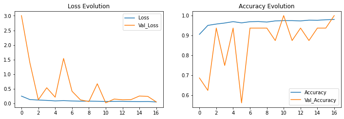

```python
plt.figure(figsize=(12, 8))

plt.subplot(2, 2, 1)
plt.plot(history_fine.history['loss'], label='Loss')
plt.plot(history_fine.history['val_loss'], label='Val_Loss')
plt.legend()
plt.title('Loss Evolution')

plt.subplot(2, 2, 2)
plt.plot(history_fine.history['accuracy'], label='Accuracy')
plt.plot(history_fine.history['val_accuracy'], label='Val_Accuracy')
plt.legend()
plt.title('Accuracy Evolution')
```

```python
loss = score_tl_test[0]
acc = score_tl_test[1]
precision = score_tl_test[2]
recall = score_tl_test[3]
fn = score_tl_test[4]
fp = score_tl_test[5]
tn = score_tl_test[6]
tp = score_tl_test[7]
auc = score_tl_test[8]

cm = [[tn, fp],[fn,tp]]
print('CONFUSION MATRIX ------------------')
print(cm)

print('\nTEST METRICS ----------------------')
print('Accuracy: {}%'.format(acc))
print('Loss: {}%'.format(loss))
print('Precision: {}%'.format(precision))
print('Recall: {}%'.format(recall))
print('F1-score: {}'.format(2*precision*recall/(precision+recall)))
print('AUC: {}%'.format(auc))

print('\nTRAIN METRIC ----------------------')
print('Train acc: {}'.format(np.round((history_fine.history['accuracy'][-1])*100, 2)))
```

```
CONFUSION MATRIX ------------------
[[207.0, 27.0], [12.0, 378.0]]

TEST METRICS ----------------------
Accuracy: 0.9375%
Loss: 0.211607426404953%
Precision: 0.9333333373069763%
Recall: 0.9692307710647583%
F1-score: 0.9509433991716357
AUC: 0.9762765169143677%

TRAIN METRIC ----------------------
Train acc: 98.06
```